# PRAK 2 MPDW ARSYA HERMANTO M0401241125

2026-08-30

```r
library("forecast")
```

```r
library("graphics")
library("TTR")
library("TSA")
library(rio)
```

# Data (import,eksplorasi,pembagian)

```r
library(readxl)
data<-read_xlsx("C:\\Users\\Asus\\Documents\\MPDW Prak 1 2024.xlsx")

head(data)
```

```
## # A tibble: 6 × 2
##   Tanggal    `Beban_Listrik _(MW)`
##   <chr>                      <dbl>
## 1 2024-01-01                42471.
## 2 2024-01-02                53286.
## 3 2024-01-03                56428.
## 4 2024-01-04                57601.
## 5 2024-01-05                56976.
## 6 2024-01-06                51921.
```

```r
# Melihat struktur data
str(data)
```

```
## tibble [366 × 2] (S3: tbl_df/tbl/data.frame)
##  $ Tanggal            : chr [1:366] "2024-01-01" "2024-01-02" "2024-01-03" "2024-01-04" ...
##  $ Beban_Listrik _(MW): num [1:366] 42471 53286 56428 57601 56976 ...
```

```r
# Melihat nama kolom
names(data)
```

```
## [1] "Tanggal"             "Beban_Listrik _(MW)"
```

```r
# Melihat jumlah baris dan kolom
dim(data)
```

```
## [1] 366   2
```

```r
# Ringkasan data
summary(data)
```

```
##    Tanggal          Beban_Listrik _(MW)
##  Length:366         Min.   :37485
##  Class :character   1st Qu.:49203
##  Mode  :character   Median :53310
##                     Mean   :52995
##                     3rd Qu.:57045
##                     Max.   :66289
```

```r
data$Tanggal <- as.Date(data$Tanggal)
head(data$Tanggal)
```

```
## [1] "2024-01-01" "2024-01-02" "2024-01-03" "2024-01-04" "2024-01-05"
## [6] "2024-01-06"
```

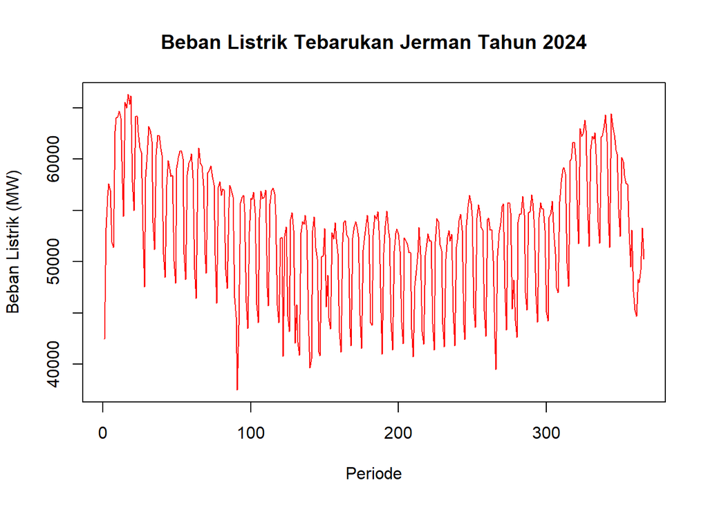

```r
data.ts <- ts(data[["Beban_Listrik _(MW)"]])

plot(data.ts,
     main = "Beban Listrik Tebarukan Jerman Tahun 2024",
     xlab = "Periode",
     ylab = "Beban Listrik (MW)",
     type = "l",
     col="red")
```

```r
n <- nrow(data)

# 80% data untuk training
n_train <- floor(0.8 * n)

# Data training
training <- data[1:n_train, ]

# Data testing
testing <- data[(n_train + 1):n, ]

nrow(training)
```

```
## [1] 292
```

```r
nrow(testing)
```

```
## [1] 74
```

```r
train.ts <- ts(training[["Beban_Listrik _(MW)"]])
test.ts <- ts(testing[["Beban_Listrik _(MW)"]])

length(train.ts)
```

```
## [1] 292
```

```r
length(test.ts)
```

```
## [1] 74
```

# Single Moving Average (SMA) m=7

## Data Traning SMA

```r
m <- 7

# Menghitung nilai pemulusan SMA
data.sma <- SMA(train.ts, n = m)

data.sma
```

```
## Time Series:
## Start = 1
## End = 292
## Frequency = 1
##   [1]       NA       NA       NA       NA       NA       NA 52870.44 55764.33
##   [9] 57294.77 58390.34 59398.42 60404.85 61220.86 61651.40 62052.27 62189.21
##  [17] 62502.35 62597.88 62904.96 62923.37 62999.52 62804.80 62688.64 62165.30
##  [25] 61565.72 60783.01 60108.97 59050.41 58204.28 57674.92 57752.40 57986.43
##  [33] 58140.25 58244.59 58762.76 59071.04 59335.96 59204.36 58953.71 58761.44
##  [41] 58324.40 57940.53 57521.77 57175.88 56763.22 56378.47 56090.52 55997.45
##  [49] 55914.46 56147.93 56178.76 56381.32 56730.74 56965.73 57057.40 57111.20
##  [57] 57019.62 56947.33 56819.71 56787.32 56515.92 56303.57 56037.83 56121.23
##  [65] 56331.79 56293.39 56120.41 56018.14 56224.34 56578.28 56523.85 56209.08
##  [73] 56170.52 56015.18 56025.15 56020.29 55598.21 55394.10 55240.91 54830.33
##  [81] 54661.70 54585.47 54384.09 54591.59 54303.66 54253.94 54319.00 54212.22
```

[output cut: 26 more lines]

```r
# Nilai ramalan untuk data training
data.ramal <- c(
  rep(NA, m),
  data.sma[m:(length(train.ts) - 1)]
)

data.ramal
```

```
##   [1]       NA       NA       NA       NA       NA       NA       NA 52870.44
##   [9] 55764.33 57294.77 58390.34 59398.42 60404.85 61220.86 61651.40 62052.27
##  [17] 62189.21 62502.35 62597.88 62904.96 62923.37 62999.52 62804.80 62688.64
##  [25] 62165.30 61565.72 60783.01 60108.97 59050.41 58204.28 57674.92 57752.40
##  [33] 57986.43 58140.25 58244.59 58762.76 59071.04 59335.96 59204.36 58953.71
##  [41] 58761.44 58324.40 57940.53 57521.77 57175.88 56763.22 56378.47 56090.52
##  [49] 55997.45 55914.46 56147.93 56178.76 56381.32 56730.74 56965.73 57057.40
##  [57] 57111.20 57019.62 56947.33 56819.71 56787.32 56515.92 56303.57 56037.83
##  [65] 56121.23 56331.79 56293.39 56120.41 56018.14 56224.34 56578.28 56523.85
##  [73] 56209.08 56170.52 56015.18 56025.15 56020.29 55598.21 55394.10 55240.91
##  [81] 54830.33 54661.70 54585.47 54384.09 54591.59 54303.66 54253.94 54319.00
##  [89] 54212.22 52710.48 52054.06 50637.91 49005.02 48757.61 48665.89 48685.81
##  [97] 49887.68 50086.03 50945.02 52248.41 52313.16 52283.77 52326.75 52311.75
## [105] 52280.95 52363.94 52559.21 52663.96 52673.67 52604.60 52923.15 53161.15
## [113] 53395.10 53591.37 53586.27 53737.80 53788.82 53446.17 53200.18 52964.18
```

[output cut: 22 more lines]

```r
data.gab <- cbind(
  Aktual = train.ts,
  Pemulusan = data.sma,
  Ramalan = data.ramal
)

head(data.gab, 21)
```

```
## Time Series:
## Start = 1
## End = 21
## Frequency = 1
##      Aktual Pemulusan  Ramalan
##  1 42470.79        NA       NA
##  2 53286.46        NA       NA
##  3 56428.30        NA       NA
##  4 57600.81        NA       NA
##  5 56976.38        NA       NA
##  6 51920.74        NA       NA
##  7 51409.58  52870.44       NA
##  8 62728.04  55764.33 52870.44
##  9 63999.55  57294.77 55764.33
## 10 64097.25  58390.34 57294.77
## 11 64657.38  59398.42 58390.34
## 12 64021.42  60404.85 59398.42
## 13 57632.78  61220.86 60404.85
## 14 54423.35  61651.40 61220.86
## 15 65534.16  62052.27 61651.40
## 16 64958.11  62189.21 62052.27
## 17 66289.24  62502.35 62189.21
## 18 65326.08  62597.88 62502.35
## 19 66170.97  62904.96 62597.88
## 20 57761.71  62923.37 62904.96
## 21 54956.34  62999.52 62923.37
```

### Plot SMA Traning

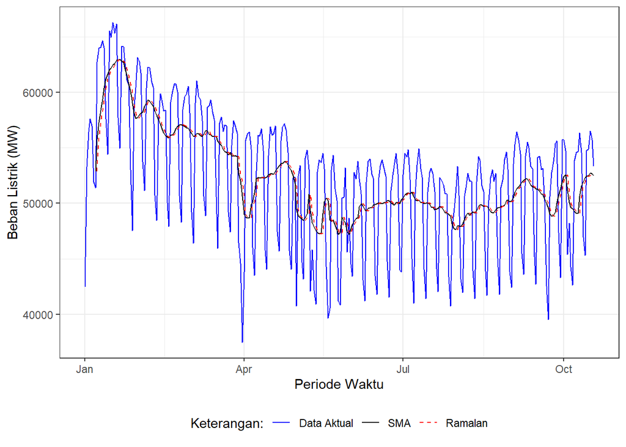

```r
library(ggplot2)
ggplot() +

  # Data aktual
  geom_line(
    data = training,
    aes(
      x = Tanggal,
      y = `Beban_Listrik _(MW)`,
      col = "Data Aktual")
  ) +

  # Hasil pemulusan SMA
  geom_line(
    data = data.frame(
      Tanggal = training$Tanggal,
      SMA = as.numeric(data.sma)
    ),
    aes(
      x = Tanggal,
      y = SMA,
      col = "SMA"
    ),
    na.rm = TRUE
  ) +

  # Ramalan
  geom_line(
    data = data.frame(
      Tanggal = training$Tanggal,
      Ramalan = as.numeric(data.ramal)
    ),
    aes(
      x = Tanggal,
      y = Ramalan,
      col = "Ramalan"
    ),
    linetype = "dashed",
    na.rm = TRUE
  ) +

  labs(
    x = "Periode Waktu",
    y = "Beban Listrik (MW)",
    color = "Legend"
  ) +

  scale_colour_manual(
    name = "Keterangan:",
    breaks = c("Data Aktual", "SMA", "Ramalan"),
    values = c(
      "Data Aktual" = "blue",
      "SMA" = "black",
      "Ramalan" = "red"
    )
  ) +

  theme_bw() +

  theme(legend.position = "bottom",
        plot.caption = element_text(hjust=0.5, size=12))
```

### Akurasi data training

```r
# Error
error_train.sma <- train.ts - data.ramal

# Ambil error yang bukan NA
error_train.sma <- na.omit(error_train.sma)

# SSE
SSE_train.sma <- sum(error_train.sma^2)

# MSE
MSE_train.sma <- mean(error_train.sma^2)

# RMSE
RMSE_train.sma <- sqrt(MSE_train.sma)

# MAPE
MAPE_train.sma <- mean(
  abs(
    error_train.sma /
      train.ts[(m + 1):length(train.ts)]
  ) * 100
)

# Tabel akurasi
akurasi_train.sma <- matrix(
  c(
    SSE_train.sma,
    MSE_train.sma,
    RMSE_train.sma,
    MAPE_train.sma
  )
)

rownames(akurasi_train.sma) <- c(
  "SSE",
  "MSE",
  "RMSE",
  "MAPE"
)

colnames(akurasi_train.sma) <- "SMA m = 7"

akurasi_train.sma
```

```
##         SMA m = 7
## SSE  7.241519e+09
## MSE  2.540884e+07
## RMSE 5.040718e+03
## MAPE 8.812348e+00
```

## SMA data testing

```r
n_test <- length(test.ts)

# Forecast menggunakan SMA terakhir
forecast_test.sma <- rep(
  tail(data.sma, 1),
  n_test
)

forecast_test.sma
```

```
##  [1] 52501.15 52501.15 52501.15 52501.15 52501.15 52501.15 52501.15 52501.15
##  [9] 52501.15 52501.15 52501.15 52501.15 52501.15 52501.15 52501.15 52501.15
## [17] 52501.15 52501.15 52501.15 52501.15 52501.15 52501.15 52501.15 52501.15
## [25] 52501.15 52501.15 52501.15 52501.15 52501.15 52501.15 52501.15 52501.15
## [33] 52501.15 52501.15 52501.15 52501.15 52501.15 52501.15 52501.15 52501.15
## [41] 52501.15 52501.15 52501.15 52501.15 52501.15 52501.15 52501.15 52501.15
## [49] 52501.15 52501.15 52501.15 52501.15 52501.15 52501.15 52501.15 52501.15
## [57] 52501.15 52501.15 52501.15 52501.15 52501.15 52501.15 52501.15 52501.15
## [65] 52501.15 52501.15 52501.15 52501.15 52501.15 52501.15 52501.15 52501.15
## [73] 52501.15 52501.15
```

### Akurasi Data testing

```r
# Error
error_test.sma <- test.ts - forecast_test.sma

# SSE
SSE_test.sma <- sum(error_test.sma^2)

# MSE
MSE_test.sma <- mean(error_test.sma^2)

# RMSE
RMSE_test.sma <- sqrt(MSE_test.sma)

# MAPE
MAPE_test.sma <- mean(
  abs(error_test.sma / test.ts) * 100
)

# Tabel akurasi
akurasi_test.sma <- matrix(
  c(
    SSE_test.sma,
    MSE_test.sma,
    RMSE_test.sma,
    MAPE_test.sma
  )
)

rownames(akurasi_test.sma) <- c(
  "SSE",
  "MSE",
  "RMSE",
  "MAPE"
)

colnames(akurasi_test.sma) <- "SMA m = 7"

akurasi_test.sma
```

```
##         SMA m = 7
## SSE  3.245138e+09
## MSE  4.385322e+07
## RMSE 6.622176e+03
## MAPE 9.887005e+00
```

## KESIMPULAN SMA

Metode Single Moving Average (SMA) dengan m=7 mampu memberikan hasil peramalan yang cukup baik dalam mengikuti pola data beban listrik. Dari hasil evaluasi, metode SMA menghasilkan nilai MAPE sebesar 9,887% pada data testing sehingga tingkat akurasinya dapat dikategorikan baik. Namun, metode ini masih memiliki keterbatasan dalam menangkap perubahan tren karena peramalan didasarkan pada rata-rata beberapa periode sebelumnya.

# Double Moving Average (DMA)

```r
m <- 7

# SMA pertama
S1 <- SMA(train.ts, n = m)

# SMA kedua
S2 <- SMA(S1, n = m)

# Nilai level
At <- 2 * S1 - S2

# Nilai trend
Bt <- 2 / (m - 1) * (S1 - S2)

# Ramalan DMA
ramalan_dma <- At + Bt
```

```r
head(S1, 21)
```

```
## Time Series:
## Start = 1
## End = 21
## Frequency = 1
##  [1]       NA       NA       NA       NA       NA       NA 52870.44 55764.33
##  [9] 57294.77 58390.34 59398.42 60404.85 61220.86 61651.40 62052.27 62189.21
## [17] 62502.35 62597.88 62904.96 62923.37 62999.52
```

```r
head(S2, 21)
```

```
## Time Series:
## Start = 1
## End = 21
## Frequency = 1
##  [1]       NA       NA       NA       NA       NA       NA       NA       NA
##  [9]       NA       NA       NA       NA 57906.29 59160.71 60058.99 60758.19
## [17] 61345.62 61802.69 62159.84 62403.06 62595.65
```

```r
head(ramalan_dma, 21)
```

```
## Time Series:
## Start = 1
## End = 21
## Frequency = 1
##  [1]       NA       NA       NA       NA       NA       NA       NA       NA
##  [9]       NA       NA       NA       NA 65640.29 64972.31 64709.98 64097.23
## [17] 64044.65 63658.13 63898.44 63617.13 63538.00
```

## Akurasi Data traning

```r
hasil_train.dma <- data.frame(
  Aktual = as.numeric(train.ts),
  Ramalan = as.numeric(ramalan_dma)
)

# Hapus NA
hasil_train.dma <- na.omit(hasil_train.dma)

# Error
error_train.dma <- hasil_train.dma$Aktual -
                   hasil_train.dma$Ramalan

# SSE
SSE_train.dma <- sum(error_train.dma^2)

# MSE
MSE_train.dma <- mean(error_train.dma^2)

# RMSE
RMSE_train.dma <- sqrt(MSE_train.dma)

# MAPE
MAPE_train.dma <- mean(
  abs(error_train.dma / hasil_train.dma$Aktual) * 100
)

# Tabel akurasi
akurasi_train.dma <- matrix(
  c(
    SSE_train.dma,
    MSE_train.dma,
    RMSE_train.dma,
    MAPE_train.dma
  )
)

rownames(akurasi_train.dma) <- c(
  "SSE",
  "MSE",
  "RMSE",
  "MAPE"
)

colnames(akurasi_train.dma) <- "DMA m = 7"

akurasi_train.dma
```

```
##         DMA m = 7
## SSE  6.749577e+09
## MSE  2.410563e+07
## RMSE 4.909749e+03
## MAPE 8.449170e+00
```

## AKurasi Testing

```r
n_test <- length(test.ts)

# Ambil nilai At dan Bt terakhir dari data training
At_akhir <- as.numeric(tail(na.omit(At), 1))
Bt_akhir <- as.numeric(tail(na.omit(Bt), 1))

# Forecast sebanyak jumlah data testing
forecast_test.dma <- At_akhir +
                     Bt_akhir * (1:n_test)

# Cek panjang
length(test.ts)
```

```
## [1] 74
```

```r
length(forecast_test.dma)
```

```
## [1] 74
```

```r
error_test.dma <- as.numeric(test.ts) -
                  as.numeric(forecast_test.dma)

# SSE
SSE_test.dma <- sum(error_test.dma^2)

# MSE
MSE_test.dma <- mean(error_test.dma^2)

# RMSE
RMSE_test.dma <- sqrt(MSE_test.dma)

# MAPE
MAPE_test.dma <- mean(
  abs(
    error_test.dma / as.numeric(test.ts)
  ) * 100
)

# Tabel akurasi
akurasi_test.dma <- matrix(
  c(
    SSE_test.dma,
    MSE_test.dma,
    RMSE_test.dma,
    MAPE_test.dma
  )
)

rownames(akurasi_test.dma) <- c(
  "SSE",
  "MSE",
  "RMSE",
  "MAPE"
)

colnames(akurasi_test.dma) <- "DMA m = 7"

akurasi_test.dma
```

```
##         DMA m = 7
## SSE  2.980706e+09
## MSE  4.027981e+07
## RMSE 6.346638e+03
## MAPE 9.661261e+00
```

## Plot

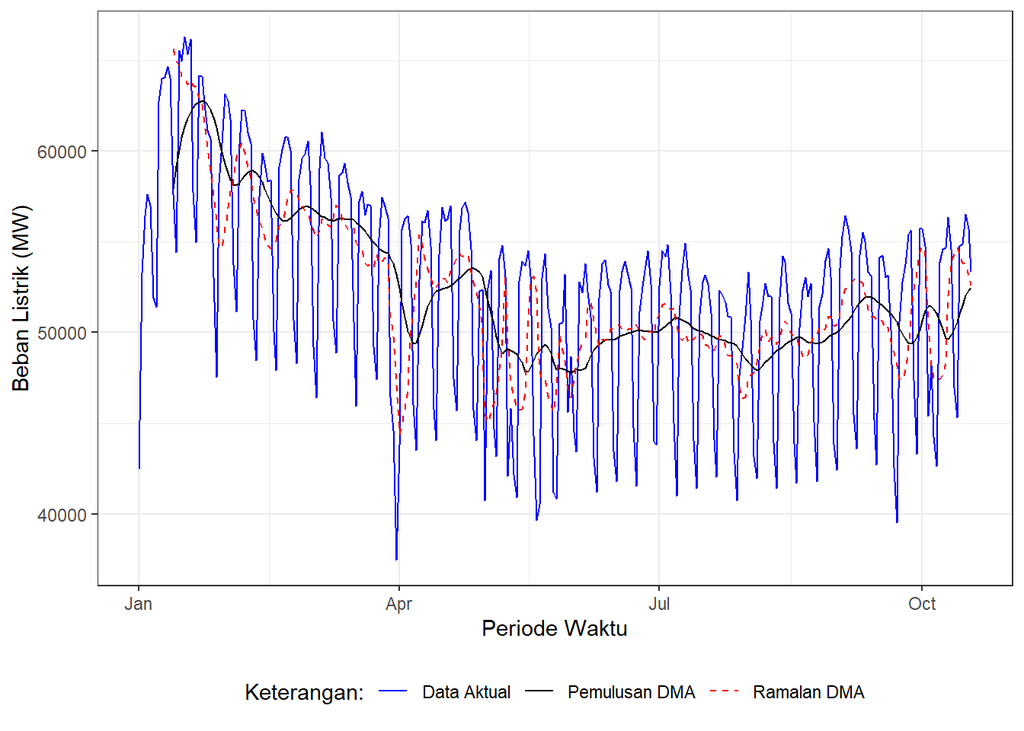

```r
library(ggplot2)

plot_dma <- data.frame(
  Tanggal = training$Tanggal,
  Aktual = as.numeric(train.ts),
  Pemulusan = as.numeric(S2),
  Ramalan = as.numeric(ramalan_dma)
)

ggplot() +

  # Data Aktual
  geom_line(
    data = plot_dma,
    aes(
      x = Tanggal,
      y = Aktual,
      col = "Data Aktual"
    )
  ) +

  # Pemulusan DMA
  geom_line(
    data = plot_dma,
    aes(
      x = Tanggal,
      y = Pemulusan,
      col = "Pemulusan DMA"
    ),
    na.rm = TRUE
  ) +

  # Ramalan DMA
  geom_line(
    data = plot_dma,
    aes(
      x = Tanggal,
      y = Ramalan,
      col = "Ramalan DMA"
    ),
    linetype = "dashed",
    na.rm = TRUE
  ) +

  labs(
    x = "Periode Waktu",
    y = "Beban Listrik (MW)",
    color = "Legend"
  ) +

  scale_colour_manual(
    name = "Keterangan:",
    breaks = c(
      "Data Aktual",
      "Pemulusan DMA",
      "Ramalan DMA"
    ),
    values = c(
      "Data Aktual" = "blue",
      "Pemulusan DMA" = "black",
      "Ramalan DMA" = "red"
    )
  ) +

  theme_bw() +

  theme(
    legend.position = "bottom"
  )
```

## KESIMPULAN DMA

Metode Double Moving Average (DMA) dengan m=7 mampu memberikan hasil peramalan yang cukup baik dalam mengikuti pola dan perubahan tren data beban listrik. Berdasarkan hasil evaluasi, metode DMA menghasilkan nilai MAPE sebesar 9,661% pada data testing sehingga tingkat akurasinya dapat dikategorikan baik. Metode ini lebih mampu menangkap perubahan tren dibandingkan SMA karena proses peramalannya menggunakan dua tahap pemulusan serta mempertimbangkan komponen tren.

# Single Exponential Smoothing (SES)

```r
alpha <- 0.2

data.ses <- HoltWinters(
  train.ts,
  alpha = alpha,
  beta = FALSE,
  gamma = FALSE
)

# Pemulusan SES
pemulusan_ses <- c(
  NA,
  as.numeric(data.ses$fitted[, "xhat"])
)

# Ramalan SES
ramalan_ses <- c(
  NA,
  as.numeric(data.ses$fitted[, "xhat"])
)

# Cek panjang
length(training$Tanggal)
```

```
## [1] 292
```

```r
length(train.ts)
```

```
## [1] 292
```

```r
length(pemulusan_ses)
```

```
## [1] 292
```

```r
length(ramalan_ses)
```

```
## [1] 292
```

## Akurasi Data traning

```r
hasil_train.ses <- data.frame(
  Aktual = as.numeric(train.ts),
  Ramalan = as.numeric(ramalan_ses)
)

hasil_train.ses <- na.omit(hasil_train.ses)

# Error
error_train.ses <- hasil_train.ses$Aktual -
                   hasil_train.ses$Ramalan

# SSE
SSE_train.ses <- sum(error_train.ses^2)

# MSE
MSE_train.ses <- mean(error_train.ses^2)

# RMSE
RMSE_train.ses <- sqrt(MSE_train.ses)

# MAPE
MAPE_train.ses <- mean(
  abs(
    error_train.ses /
    hasil_train.ses$Aktual
  ) * 100
)

# Tabel akurasi
akurasi_train.ses <- matrix(
  c(
    SSE_train.ses,
    MSE_train.ses,
    RMSE_train.ses,
    MAPE_train.ses
  )
)

rownames(akurasi_train.ses) <- c(
  "SSE",
  "MSE",
  "RMSE",
  "MAPE"
)

colnames(akurasi_train.ses) <- "SES alpha = 0.2"

akurasi_train.ses
```

```
##      SES alpha = 0.2
## SSE     8.623877e+09
## MSE     2.963532e+07
## RMSE    5.443833e+03
## MAPE    9.479443e+00
```

## Akurasi Data Testing

```r
n_test <- length(test.ts)

nilai_akhir_ses <- as.numeric(
  tail(na.omit(pemulusan_ses), 1)
)

forecast_test.ses <- rep(
  nilai_akhir_ses,
  n_test
)

forecast_test.ses
```

```
##  [1] 53407.94 53407.94 53407.94 53407.94 53407.94 53407.94 53407.94 53407.94
##  [9] 53407.94 53407.94 53407.94 53407.94 53407.94 53407.94 53407.94 53407.94
## [17] 53407.94 53407.94 53407.94 53407.94 53407.94 53407.94 53407.94 53407.94
## [25] 53407.94 53407.94 53407.94 53407.94 53407.94 53407.94 53407.94 53407.94
## [33] 53407.94 53407.94 53407.94 53407.94 53407.94 53407.94 53407.94 53407.94
## [41] 53407.94 53407.94 53407.94 53407.94 53407.94 53407.94 53407.94 53407.94
## [49] 53407.94 53407.94 53407.94 53407.94 53407.94 53407.94 53407.94 53407.94
## [57] 53407.94 53407.94 53407.94 53407.94 53407.94 53407.94 53407.94 53407.94
## [65] 53407.94 53407.94 53407.94 53407.94 53407.94 53407.94 53407.94 53407.94
## [73] 53407.94 53407.94
```

```r
error_test.ses <- as.numeric(test.ts) -
                  as.numeric(forecast_test.ses)

# SSE
SSE_test.ses <- sum(error_test.ses^2)

# MSE
MSE_test.ses <- mean(error_test.ses^2)

# RMSE
RMSE_test.ses <- sqrt(MSE_test.ses)

# MAPE
MAPE_test.ses <- mean(
  abs(
    error_test.ses /
    as.numeric(test.ts)
  ) * 100
)

# Tabel akurasi
akurasi_test.ses <- matrix(
  c(
    SSE_test.ses,
    MSE_test.ses,
    RMSE_test.ses,
    MAPE_test.ses
  )
)

rownames(akurasi_test.ses) <- c(
  "SSE",
  "MSE",
  "RMSE",
  "MAPE"
)

colnames(akurasi_test.ses) <- "SES alpha = 0.2"

akurasi_test.ses
```

```
##      SES alpha = 0.2
## SSE     2.880508e+09
## MSE     3.892578e+07
## RMSE    6.239053e+03
## MAPE    9.459564e+00
```

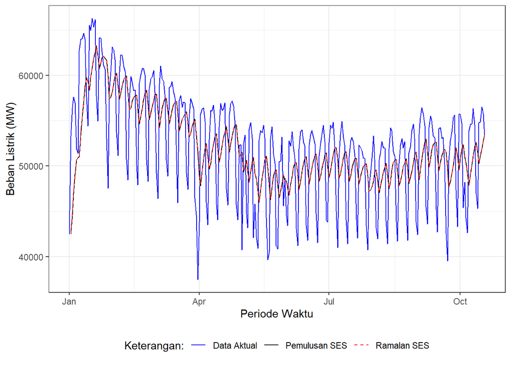

```r
plot_ses <- data.frame(
  Tanggal = training$Tanggal,
  Aktual = as.numeric(train.ts),
  Pemulusan = as.numeric(pemulusan_ses),
  Ramalan = as.numeric(ramalan_ses)
)

ggplot() +

  # Data Aktual
  geom_line(
    data = plot_ses,
    aes(
      x = Tanggal,
      y = Aktual,
      col = "Data Aktual"
    )
  ) +

  # Pemulusan SES
  geom_line(
    data = plot_ses,
    aes(
      x = Tanggal,
      y = Pemulusan,
      col = "Pemulusan SES"
    ),
    na.rm = TRUE
  ) +

  # Ramalan SES
  geom_line(
    data = plot_ses,
    aes(
      x = Tanggal,
      y = Ramalan,
      col = "Ramalan SES"
    ),
    linetype = "dashed",
    na.rm = TRUE
  ) +

  labs(
    x = "Periode Waktu",
    y = "Beban Listrik (MW)",
    color = "Legend"
  ) +

  scale_colour_manual(
    name = "Keterangan:",
    breaks = c(
      "Data Aktual",
      "Pemulusan SES",
      "Ramalan SES"
    ),
    values = c(
      "Data Aktual" = "blue",
      "Pemulusan SES" = "black",
      "Ramalan SES" = "red"
    )
  ) +

  theme_bw() +

  theme(
    legend.position = "bottom"
  )
```

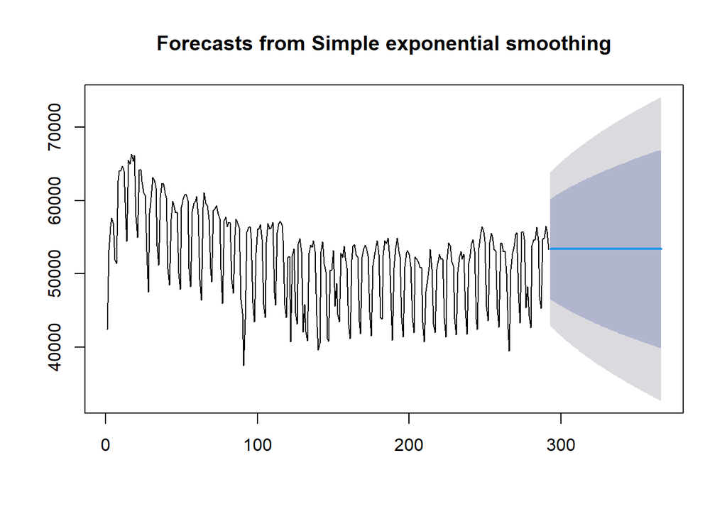

```r
ses.1 <- ses(
  train.ts,
  h = length(test.ts),
  alpha = 0.2
)

ses.2 <- ses(
  train.ts,
  h = length(test.ts),
  alpha = 0.8
)

plot(ses.1)
```

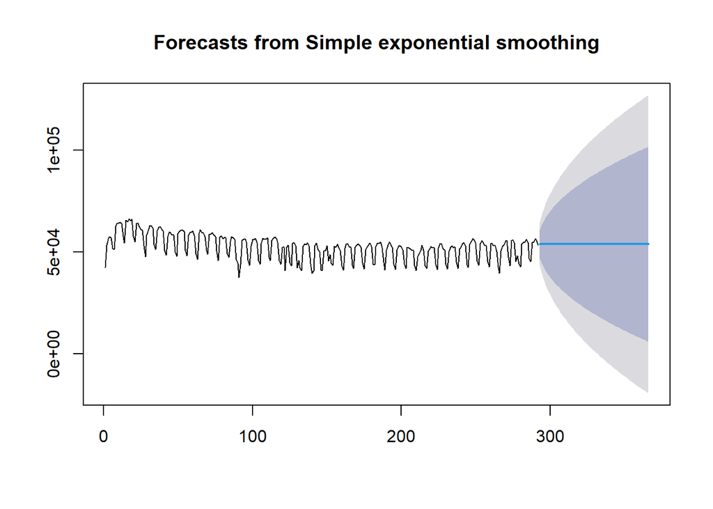

```r
plot(ses.2)
```

## Kesimpulan SES